# HW_regression

Dmitrii Belousov

2024-12-28

```r
library(lavaan)
```

```r
library(semPlot)
library(tidyverse)
library(gtsummary)
library(modelsummary)
library(GGally)
library(broom)
library(ggfortify)
library(ggResidpanel)
library(performance)
library(lmtest)
library(sandwich)
library(emmeans)
```

# Data Import

```r
data <- readxl::read_xlsx("../data/HW_data.xlsx")
```

According to the provided description, we may assume that these variables possibly are associated with physical activity:

**DRQSDT8** - Weight gain/Muscle building diet - *we may suggest that people use this diet only in case when they workout* **DRQSDT10** - High protein diet - *this kind of diet can be linked to active workout regime, this can be a part of inactive weight loosing program though* **PAQ605** - Vigorous work activity **PAQ610** - Number of days vigorous work **PAD615** - Minutes vigorous-intensity work - *I suppose, this is the best factor reflecting physical activity at work, the factor is the most subjective though* **PAQ635** - Walk or bicycle **PAQ640** - Number of days walk or bicycle **PAD645** - Minutes walk/bicycle for transportation **PAQ650** - Vigorous recreational activities **PAQ655** - Days vigorous recreational activities **PAD660** - Minutes vigorous recreational activities

Let’s inspect them:

```r
new_names <- c(
  "Weight.gain.diet", "High.protein.diet", "Vigorous.work",
  "Vigorous.work.days", "Vigorous.work.min", "Walk.bicycle",
  "Walk.bicycle.days", "Walk.bicycle.min", "Vigorous.recr",
  "Vigorous.recr.days", "Vigorous.recr.min"
)

data %>%
  select(
    DRQSDT8, DRQSDT10, PAQ605, PAQ610, PAD615, PAQ635,
    PAQ640, PAD645, PAQ650, PAQ655, PAD660
  ) %>%
  rename_with(~ new_names) %>%
  tbl_summary(
    type = list(all_continuous() ~ "continuous2"),
  statistic = list(
    all_continuous() ~ c("{mean} ({sd})", "{median} ({p25}-{p75})", "{min}-{max}")
  )) %>%
  modify_footnote(everything() ~ NA) %>%
  bold_labels()
```

| **Characteristic** | **N = 916** |
| --- | --- |
| Weight.gain.diet |  |
| 1 | 5 (0.5%) |
| 2 | 911 (99%) |
| High.protein.diet |  |
| 1 | 4 (0.4%) |
| 2 | 912 (100%) |
| Vigorous.work |  |
| 1 | 176 (19%) |
| 2 | 740 (81%) |
| Vigorous.work.days |  |
| 0 | 740 (81%) |
| 1 | 19 (2.1%) |
| 2 | 22 (2.4%) |
| 3 | 24 (2.6%) |
| 4 | 17 (1.9%) |
| 5 | 60 (6.6%) |
| 6 | 13 (1.4%) |
| 7 | 21 (2.3%) |
| Vigorous.work.min |  |
| Mean (SD) | 32 (89) |
| Median (25%-75%) | 0 (0-0) |
| Minimum-Maximum | 0-660 |
| Walk.bicycle |  |
| 1 | 211 (23%) |
| 2 | 705 (77%) |
| Walk.bicycle.days |  |
| 0 | 705 (77%) |
| 1 | 12 (1.3%) |
| 2 | 21 (2.3%) |
| 3 | 29 (3.2%) |
| 4 | 17 (1.9%) |
| 5 | 59 (6.4%) |
| 6 | 8 (0.9%) |
| 7 | 65 (7.1%) |
| Walk.bicycle.min |  |
| Mean (SD) | 13 (39) |
| Median (25%-75%) | 0 (0-0) |
| Minimum-Maximum | 0-480 |
| Vigorous.recr |  |
| 1 | 191 (21%) |
| 2 | 725 (79%) |
| Vigorous.recr.days |  |
| 0 | 725 (79%) |
| 1 | 22 (2.4%) |
| 2 | 41 (4.5%) |
| 3 | 46 (5.0%) |
| 4 | 29 (3.2%) |
| 5 | 29 (3.2%) |
| 6 | 14 (1.5%) |
| 7 | 10 (1.1%) |
| Vigorous.recr.min |  |
| Mean (SD) | 16 (39) |
| Median (25%-75%) | 0 (0-0) |
| Minimum-Maximum | 0-360 |

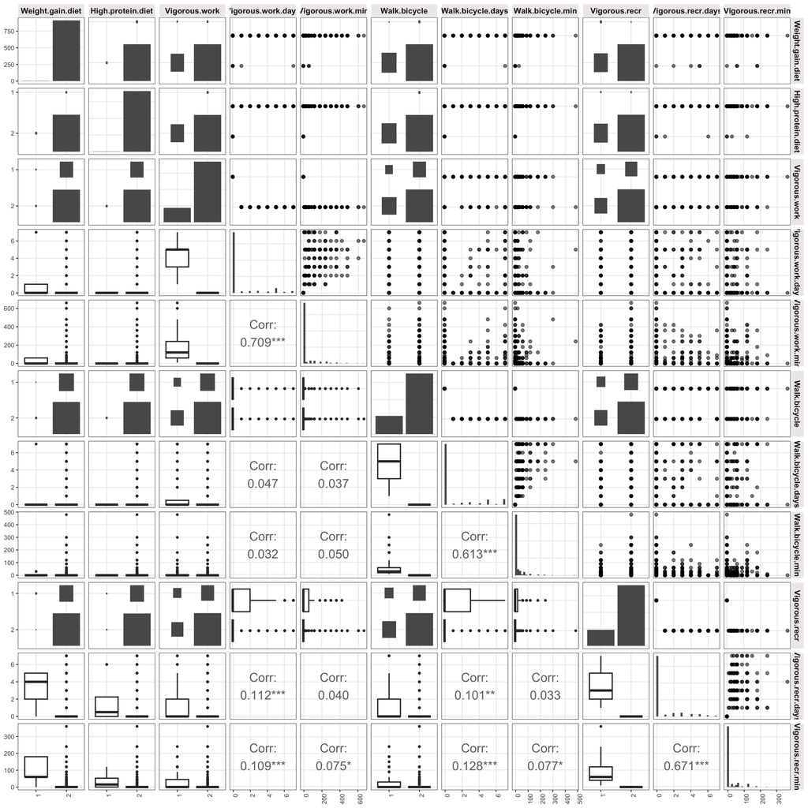

```r
data %>%
  select(
    DRQSDT8, DRQSDT10, PAQ605, PAQ610, PAD615, PAQ635,
    PAQ640, PAD645, PAQ650, PAQ655, PAD660
  ) %>%
  rename_with(~ new_names) %>%
  mutate(across(-c(Walk.bicycle.min, Walk.bicycle.days,
                 Vigorous.recr.min, Vigorous.recr.days,
                 Vigorous.work.min, Vigorous.work.days), as.factor)) %>%
  ggpairs(
  upper = list(continuous = wrap("points", alpha = 0.5, size = 1),
               combo = wrap("points", alpha = 0.5, size = 1),
               disrete = "blank"),
  lower = list(continuous = "cor",
               discrete = "count",
               combo = wrap("box_no_facet", outlier.size = 0.5)),
  diag = list(continuous = "barDiag",
              discrete = "barDiag"),
  showStrips = TRUE, progress = FALSE) +
  theme_bw(base_size = 7) +
  theme(axis.text.x = element_text(angle = 90, hjust = 1),
        panel.grid.minor = element_blank(),
        strip.placement = "outside",
        strip.background = element_rect(color = "white", fill = "#EFEBE9"),
        strip.text = element_text(size = 7, face = "bold"))
```

```r
data_ss <- data %>%
  select(
    DRQSDT8, DRQSDT10, PAQ605, PAQ610, PAD615, PAQ635,
    PAQ640, PAD645, PAQ650, PAQ655, PAD660
  ) %>%
  rename_with(~ new_names) %>%
  mutate(across(-c(Walk.bicycle.min, Walk.bicycle.days,
                 Vigorous.recr.min, Vigorous.recr.days,
                 Vigorous.work.min, Vigorous.work.days), ~ ifelse(. == 2, 0, .)))
```

```r
data_ss
```

```
## # A tibble: 916 × 11
##    Weight.gain.diet High.protein.diet Vigorous.work Vigorous.work.days
##               <dbl>             <dbl>         <dbl>              <dbl>
##  1                0                 0             0                  0
##  2                0                 0             1                  6
##  3                0                 0             1                  5
##  4                0                 0             0                  0
##  5                0                 0             0                  0
##  6                0                 0             0                  0
##  7                0                 0             1                  3
##  8                0                 0             0                  0
##  9                0                 0             0                  0
## 10                0                 0             0                  0
## # ℹ 906 more rows
## # ℹ 7 more variables: Vigorous.work.min <dbl>, Walk.bicycle <dbl>,
## #   Walk.bicycle.days <dbl>, Walk.bicycle.min <dbl>, Vigorous.recr <dbl>,
## #   Vigorous.recr.days <dbl>, Vigorous.recr.min <dbl>
```

# Задание 1.

В качестве параметра физической активности я собираюсь использовать сумму трех количественных переменных: Vigorous.work.min, Walk.bicycle.min, Vigorous.recr.min. Эта сумма, теоретически должна отражать количество минут физической активности проведенных во время работы, перемещений по городу, а так же досуга. Главная проблема такой оценки состоит в большой субъективности подобных оценок, некоторые люди могут иметь тенденцию завышать эти оценки. Можно попробовать также использовать комбинацию бинарных флагов для этих же занятий как ординальную переменную, однако в таком случае мы сталкиваемся с проблемой невозможности оценки равноценности вклада каждого из факторов между собой и между субъектами.

Могу предположить, что показатель гликированного гемоглобина может быть ассоццирован с тремя основными факторами: 1. Количество потребляемых углеводов, то есть качество и тип пищевого поведения; 2. Скорость метаболизма глюкозы в печени и других органах, скорость конвертации в другие молекулы (жирные кислоты, аминокислоты, гликоген); 3. **Потребление глюкозы мышцами**.

Создадим переменные физической активности:

```r
data %>%
  mutate(
    Physical.act.min = PAD615 + PAD645 + PAD660,

  )
```

```
## # A tibble: 916 × 75
##     SEQN DMDEDUC2 DMDHHSIZ DMDHHSZA DMDHHSZB DMDHHSZE DMDMARTL INDFMIN2 RIAGENDR
##    <dbl>    <dbl>    <dbl>    <dbl>    <dbl>    <dbl>    <dbl>    <dbl>    <dbl>
##  1 81603        4        1        0        0        1        2        4        2
##  2 81783        5        3        0        1        0        1       12        1
##  3 80825        3        5        0        2        0        1        7        1
##  4 74081        4        2        0        0        2        1        5        1
##  5 83352        3        6        0        1        1        5       12        1
##  6 79661        3        7        1        2        0        1       12        1
##  7 77680        4        5        0        0        0        5       12        1
##  8 77727        5        5        1        0        2        1       11        2
##  9 77013        5        5        0        2        0        5       12        1
## 10 75699        1        5        0        2        1        5        4        2
## # ℹ 906 more rows
## # ℹ 66 more variables: RIDAGEYR <dbl>, RIDRETH3 <dbl>, DR1TALCO <dbl>,
## #   DR1TCHOL <dbl>, DR1TFIBE <dbl>, DR1TKCAL <dbl>, DR1TMFAT <dbl>,
## #   DR1TPFAT <dbl>, DR1TSFAT <dbl>, DR1TSUGR <dbl>, DR1TTFAT <dbl>,
## #   DRD340 <dbl>, DRD360 <dbl>, DRQSDIET <dbl>, DRQSDT1 <dbl>, DRQSDT10 <dbl>,
## #   DRQSDT2 <dbl>, DRQSDT3 <dbl>, DRQSDT4 <dbl>, DRQSDT7 <dbl>, DRQSDT8 <dbl>,
## #   DRQSDT9 <dbl>, DRQSDT91 <dbl>, BMXBMI <dbl>, BMXHT <dbl>, BMXWT <dbl>, …
```

# Задание 2.

На первом этапе я собираюсь включить в модель все конфаундеры, а затем, если необходимо, убрать те, которые не объясняют никакой дополнительной вариации отклика, при помощи goodness-of-fit тестов. Также необходимо учесть наличие инструментальной переменной, на первом этапе, я буду контролировать то, что она не скоррелирована с зависмой перменной (физической активностью) и нескоррелирована с остатками модели.

Помимо включенных в граф факторов, я также считаю необходимым внести в модель фактор, отражающий потребление углеводов.

*бонусное задание* Race - конфаундер Education - конфаундер Family income - конфаундер Smoking - прокси-конфаундер Age - конфаундер Comorbidities - конфаундер Sex - конфаундер Blood pressure - коллайдер Diabetic medication - коллайдер Marital status - instrumental variable